# Data Analysis of COVID-19 Based on a Case Study of Taiwan

**Author: Yu-Hsiang Su**  
**Data up to 20/04/2020**  
**Contact Email: tommy11305@gmail.com**

## 1. Introduction

In this project, the data analysis of COVID-19 is based on a case study of **Taiwan**. There are three sections in the project,

1. A brief overview of the COVID-19 in Taiwan and its trend
2. Distribution of the COVID-19 confirmed cases based on different categories
3. The relations between total confirmed cases, deaths and recovery cases

### Data Preprocessing and Overview

```python
import matplotlib
matplotlib.use('Agg')
from datascience import *
%matplotlib inline
import matplotlib.pyplot as plt
import matplotlib.dates as mdates
from matplotlib.dates import DateFormatter
import numpy as np
plt.style.use('default')
import datetime
import pandas as pd
import geopandas as gp
import seaborn as sns
```

The datasets are collected and downloaded from

1. 嚴重特殊傳染性肺炎 Taiwan CDC 公布病例資訊 Daily updated
2. [台灣衛生福利部疾病管制署(CDC)](https://data.cdc.gov.tw/dataset/aagstable-weekly-19cov) Weekly updated
3. [kaggle Novel Corona Virus 2019 Dataset](https://www.kaggle.com/sudalairajkumar/novel-corona-virus-2019-dataset/data#covid_19_data.csv) Daily updated

```python
Covid19_Taiwan = Table.read_table('嚴重特殊傳染性肺炎 Taiwan CDC 公布病例資訊 - 確診病例.csv')
Covid19_Taiwan = Covid19_Taiwan.drop('CDC 新聞稿 URL').drop('就醫日').drop('群組').drop('確診前症狀').drop('其他公布說明').drop('Unnamed: 13').drop('個案頁面建立').drop('相關地點')

Covid19_cases = Covid19_Taiwan.group(['確診日', '境外或是本土'])
Covid19_cases_domestic = Covid19_cases.where('境外或是本土', are.equal_to('本土'))
Covid19_cases_imported = Covid19_cases.where('境外或是本土', are.equal_to('境外'))
Covid19_cases_others = Covid19_cases.where('境外或是本土', are.not_equal_to('本土')).where('境外或是本土', are.not_equal_to('境外'))
Covid19_death = Covid19_Taiwan.group('死亡日')

End_date = '20200420'

date = pd.date_range('20200101', End_date)

Covid19_Taiwan_cases = Table().with_columns(
    'Date', date.date,
    'Domestic', np.zeros(len(date.date)),
    'Imported', np.zeros(len(date.date)),
    'Others', np.zeros(len(date.date)),
    'Death', np.zeros(len(date.date))
)

for i in range(Covid19_Taiwan_cases.num_rows):
    Covid19_Taiwan_cases.column('Date')[i] = str(Covid19_Taiwan_cases.column('Date').item(i))

def reconstruct(s1, s2, t1, t2):
    for i in range(t1.num_rows):
        for j in range(t2.num_rows):
            if t1.column('Date').item(i) == t2.column(s1).item(j):
                t1.column(s2)[i] = t2.column('count').item(j)
    return t1

Covid19_Taiwan_cases = reconstruct('確診日', 'Domestic', Covid19_Taiwan_cases, Covid19_cases_domestic)
Covid19_Taiwan_cases = reconstruct('確診日', 'Imported', Covid19_Taiwan_cases, Covid19_cases_imported)
Covid19_Taiwan_cases = reconstruct('確診日', 'Others', Covid19_Taiwan_cases, Covid19_cases_others)
Covid19_Taiwan_cases = reconstruct('死亡日', 'Death', Covid19_Taiwan_cases, Covid19_death)
print('First Dataset')
Covid19_Taiwan_cases.show(5)

Covid19_weekly = Table.read_table('Weekly_Confirmation_Age_County_Gender_19CoV.csv')
print('Second Dataset')
Covid19_weekly.sort('研判週別', descending = False).show(5)

Covid19_Taiwan_overall = Table.read_table('covid_19_data.csv')
Covid19_Taiwan_overall = Covid19_Taiwan_overall.where('Country/Region', are.equal_to('Taiwan')).drop('SNo').drop('Province/State').drop('Last Update').drop('Country/Region')
print('Third Dataset')
Covid19_Taiwan_overall.show(5)
```

```
First Dataset
```

| Date | Domestic | Imported | Others | Death |
| --- | --- | --- | --- | --- |
| 2020-01-01 | 0 | 0 | 0 | 0 |
| 2020-01-02 | 0 | 0 | 0 | 0 |
| 2020-01-03 | 0 | 0 | 0 | 0 |
| 2020-01-04 | 0 | 0 | 0 | 0 |
| 2020-01-05 | 0 | 0 | 0 | 0 |

... (106 rows omitted)

```
Second Dataset
```

| 確定病名 | 研判年份 | 研判週別 | 縣市 | 性別 | 是否為境外移入 | 年齡層 | 確定病例數 |
| --- | --- | --- | --- | --- | --- | --- | --- |
| 嚴重特殊傳染性肺炎 | 2020 | 4 | 台北市 | F | 是 | 50-54 | 1 |
| 嚴重特殊傳染性肺炎 | 2020 | 4 | 高雄市 | F | 是 | 55-59 | 1 |
| 嚴重特殊傳染性肺炎 | 2020 | 4 | 高雄市 | M | 是 | 55-59 | 1 |
| 嚴重特殊傳染性肺炎 | 2020 | 5 | 台中市 | F | 是 | 70+ | 2 |
| 嚴重特殊傳染性肺炎 | 2020 | 5 | 台北市 | F | 是 | 55-59 | 1 |

... (293 rows omitted)

```
Third Dataset
```

| ObservationDate | Confirmed | Deaths | Recovered |
| --- | --- | --- | --- |
| 01/22/2020 | 1 | 0 | 0 |
| 01/23/2020 | 1 | 0 | 0 |
| 01/24/2020 | 3 | 0 | 0 |
| 01/25/2020 | 3 | 0 | 0 |
| 01/26/2020 | 4 | 0 | 0 |

... (85 rows omitted)

## 2. Brief Overview of the Current Situation

In this section, the daily confirmed cases of COVID-19 and daily deaths in Taiwan are presented. Also, the total confirmed cases and total deaths are shown below in section 2.3. All the graphs below indicate the date on the x-axis.

### 2.1. COVID-19 Taiwan Daily Confirmed Cases by Infected Source

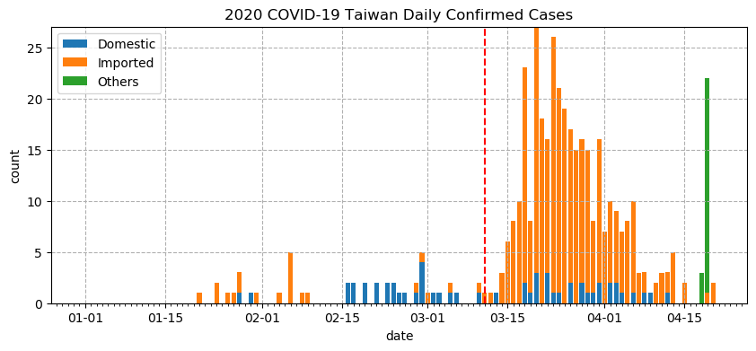

```python
fig, ax1 = plt.subplots(figsize=(10, 4))
plt.bar(date, Covid19_Taiwan_cases.column('Domestic'), label = 'Domestic')
plt.bar(date, Covid19_Taiwan_cases.column('Imported'), bottom = Covid19_Taiwan_cases.column('Domestic'),label = 'Imported')
plt.bar(date, Covid19_Taiwan_cases.column('Others'), bottom = Covid19_Taiwan_cases.column('Domestic')+Covid19_Taiwan_cases.column('Imported'),label = 'Others')
plt.axvline (x = '20200311', ymin = 0, ymax = 1, color = 'red', ls = '--')
date_form = DateFormatter("%m-%d")
ax1.xaxis.set_major_formatter(date_form)
ax1.xaxis.set_minor_locator(mdates.DayLocator(interval = 1))
plt.title('2020 COVID-19 Taiwan Daily Confirmed Cases')
plt.grid(linestyle='--')
plt.legend()
plt.xlabel('date')
plt.ylabel('count')
plt.show()
```

The red dash line in the above figure represents the time when WHO declared COVID-19 as a global pandemic. From above Taiwan daily confirmed cases, it shows that:

1. The daily confirmed cases have been separated into three different categories based on the infected sources, including **domestic**, **imported** and **others**.
2. **The counts of daily domestic cases are never above 5 cases in the past four months.**
3. **The counts of daily imported cases are usually above 15 cases from mid-March to the beginning of April.**
4. **After WHO declared COVID-19 as a global pandemic, the daily imported confirmed cases increased rapidly and reached the peak on *March 20*. Later on, the daily imported confirmed cases started to decrease gradually.**

### 2.2. COVID-19 Taiwan Daily Deaths

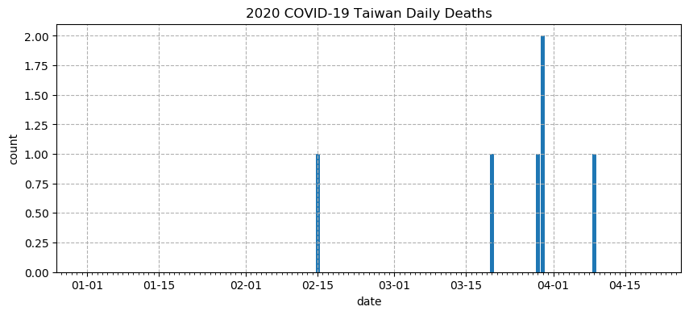

```python
fig, ax = plt.subplots(figsize=(10, 4))
plt.bar(date, Covid19_Taiwan_cases.column('Death'))
date_form = DateFormatter("%m-%d")
ax.xaxis.set_major_formatter(date_form)
ax.xaxis.set_minor_locator(mdates.DayLocator(interval = 1))
plt.title('2020 COVID-19 Taiwan Daily Deaths')
plt.grid(linestyle='--')
plt.xlabel('date')
plt.ylabel('count')
plt.show()
```

During the past four months, there are very few deaths reported from Taiwan and the maximum amount of single-day deaths is **2** cases on *March 30*.

### 2.3. COVID-19 Taiwan Total Confirmed Cases and Deaths

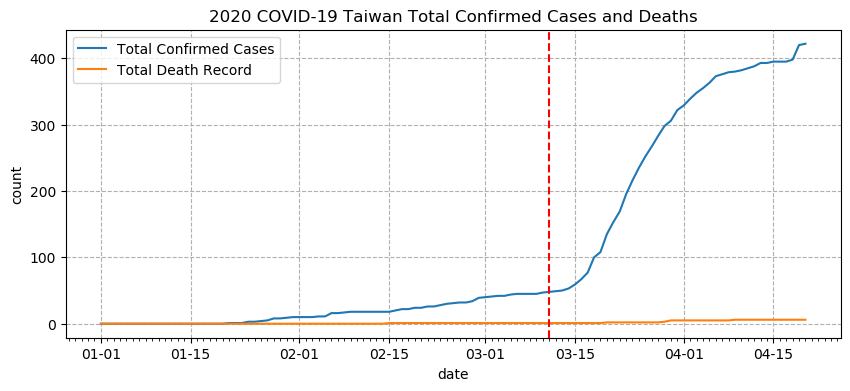

```python
Daily_confimed_cases = Covid19_Taiwan_cases.column('Domestic')+Covid19_Taiwan_cases.column('Imported')+Covid19_Taiwan_cases.column('Others')
Total_confimed_cases = Daily_confimed_cases.cumsum()
fig, ax = plt.subplots(figsize=(10, 4))
plt.plot(date, Total_confimed_cases, label = 'Total Confirmed Cases')
plt.plot(date, Covid19_Taiwan_cases.column('Death').cumsum(), label = 'Total Death Record')
date_form = DateFormatter("%m-%d")
ax.xaxis.set_major_formatter(date_form)
ax.xaxis.set_minor_locator(mdates.DayLocator(interval = 1))
plt.axvline (x = '20200311', ymin = 0, ymax = 1, color = 'red', ls = '--')
plt.legend()
plt.title('2020 COVID-19 Taiwan Total Confirmed Cases and Deaths')
plt.grid(linestyle='--')
plt.xlabel('date')
plt.ylabel('count')
plt.show()
```

Taiwan reported the first COVID-19 confirmed case on *January 21* and the first death on *February 15*. The red dash line in the above figure represents the time when WHO declared COVID-19 as a global pandemic. From the above trend, it shows that:

## 3. Distribution of COVID-19 Confirmed Cases in Taiwan by Categories

In this section, the COVID-19 confirmed cases in Taiwan are divided by different categories, including age, gender, county and infected source to analyze the distribution.

### 3.1. Distribution by Age and Gender

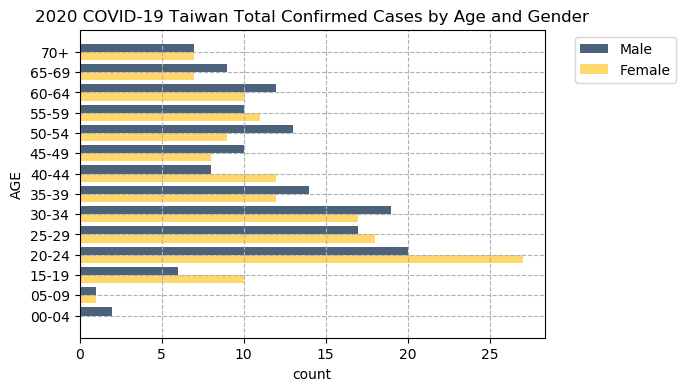

```python
Covid19_age_gender = Table().with_columns(
    '性別', Covid19_weekly.column('性別'),
    '年齡層', Covid19_weekly.column('年齡層'),
    '確定病例數', Covid19_weekly.column('確定病例數')
)

Covid19_age_m = Covid19_age_gender.where('性別', are.equal_to('M'))
for i in range(len(Covid19_age_m.column(1))):
    if Covid19_age_m.column(1).item(i) == '4':
        Covid19_age_m.column(1)[i] = '00-04'
    elif Covid19_age_m.column(1).item(i) == '5-9':
        Covid19_age_m.column(1)[i] = '05-09'
Covid19_age_m = Covid19_age_m.group('年齡層')

Covid19_age_f = Covid19_age_gender.where('性別', are.equal_to('F'))
for i in range(len(Covid19_age_f.column(1))):
    if Covid19_age_f.column(1).item(i) == '4':
        Covid19_age_f.column(1)[i] = '00-04'
    elif Covid19_age_f.column(1).item(i) == '5-9':
        Covid19_age_f.column(1)[i] = '05-09'
Covid19_age_f = Covid19_age_f.group('年齡層')
Covid19_age_f = Table().with_columns(
    '年齡層', np.append('00-04', Covid19_age_f.column(0)),
    'count', np.append(0, Covid19_age_f.column(1))
)

Covid19_age_gender_result = Covid19_age_m.join('年齡層', Covid19_age_f, '年齡層').relabel('年齡層', 'AGE').relabel('count', 'Male').relabel('count_2', 'Female')
Covid19_age_gender_result = Covid19_age_gender_result.sort('AGE', descending = True)
Covid19_age_gender_result.barh(0,height = 4)
plt.title('2020 COVID-19 Taiwan Total Confirmed Cases by Age and Gender')
plt.grid(linestyle='--')
plt.xlabel('count')
plt.show()
```

From the above bar graph of age and gender distribution, it shows that:

1. For people above 35 years old, the distribution of confirmed cases is almost equal between male and female.
2. **The only peak of confirmed cases which is counted as *27* cases happens for *female in the age between 20 to 24*.**

### 3.2. Distribution by County

#### 3.2.1. Bar Graph

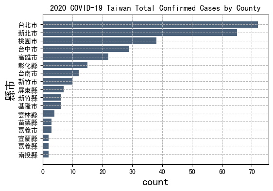

```python
plt.rcParams['font.sans-serif'] = ['simhei']
plt.rcParams['axes.unicode_minus'] = False
Covid19_county_case = Table().with_columns(
    '縣市', Covid19_weekly.column('縣市'),
    '確定病例數', Covid19_weekly.column('確定病例數'),
).group('縣市').sort('count', descending = True)

Covid19_county_case.barh('縣市', height = 4)
plt.title('2020 COVID-19 Taiwan Total Confirmed Cases by County')
plt.grid(linestyle='--')
plt.show()
```

#### 3.2.2. Pie Chart

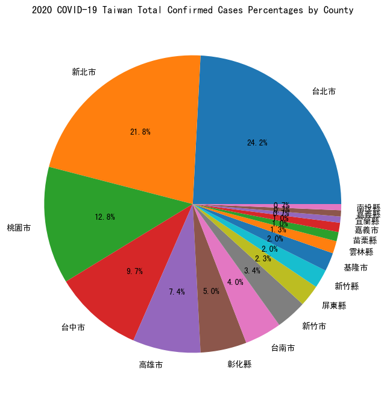

```python
Covid19_county_case = Table.to_df(Covid19_county_case)
fig, ax = plt.subplots(figsize=(8, 8))
plt.title('2020 COVID-19 Taiwan Total Confirmed Cases Percentages by County')
plt.pie(Covid19_county_case['count'],autopct = '%.1f%%', radius = 1, labels = Covid19_county_case['縣市'])
plt.show()
```

#### 3.2.3. Map

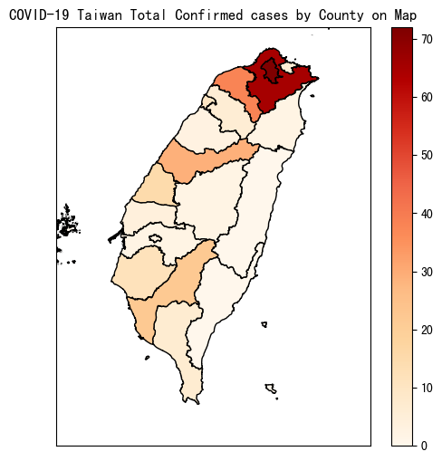

```python
county_shp = gp.read_file('Taiwan_county/COUNTY_MOI_1081121.shp', encoding='utf-8')
county_shp.loc[8, 'COUNTYNAME'] = '台北市'
county_shp.loc[10, 'COUNTYNAME'] = '台中市'
county_shp.loc[11, 'COUNTYNAME'] = '台南市'
county_shp.loc[19, 'COUNTYNAME'] = '台東縣'
county_shp = county_shp.merge(
    Covid19_county_case,
    left_on = ('COUNTYNAME'),
    right_on = ('縣市'),
    how = 'left'
)
county_shp['count'] = county_shp['count'].fillna(0)
county_shp.plot(
    cmap = 'OrRd',
    edgecolor = 'black',
    column = 'count',
    legend = True,
    figsize = (6,6)
)
plt.xlim(119.5, 122.5)
plt.ylim(21.5, 25.5)
plt.gca().xaxis.set_major_locator(plt.NullLocator())
plt.gca().yaxis.set_major_locator(plt.NullLocator())
plt.title('COVID-19 Taiwan Total Confirmed cases by County on Map')
plt.show()
```

From the above distribution map, it is clear that:

1. Most of the confirmed cases are in the **north part of Taiwan** while the situation in the **east part of Taiwan** is relatively mild with zero confirmed cases from both Hualien and Taitung.
2. Those main cities such as **Taipei City**, **New Taipei City**, **Taoyuan City**, **Taichung City** and **Kaohsiung City** have reported relatively more confirmed cases.

### 3.3. Distribution by infected source

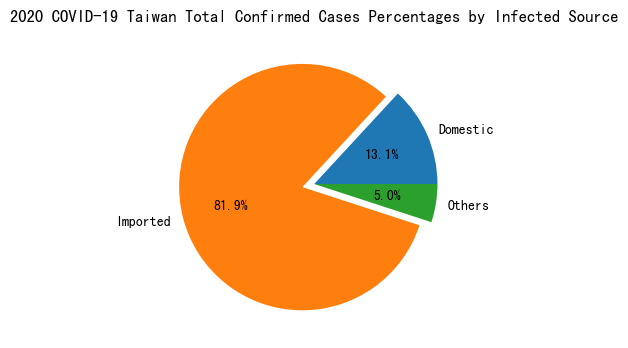

```python
fig, ax = plt.subplots(figsize=(4, 4))
plt.title('2020 COVID-19 Taiwan Total Confirmed Cases Percentages by Infected Source')
sizes = [Covid19_Taiwan_cases.column('Domestic').cumsum().max(),
         Covid19_Taiwan_cases.column('Imported').cumsum().max(),
         Covid19_Taiwan_cases.column('Others').max().cumsum()]
plt.pie(sizes, explode=(0, .1, 0), autopct = '%.1f%%', radius = 1, labels = make_array('Domestic', 'Imported', 'Others'))
plt.show()
```

From the above pie chart of total confirmed cases by infected source, it can be concluded that most of the confirmed cases are **imported cases** which is **81.9%** in total while the domestic cases and others are less than 20%.

## 4. Relations between Variables

In this section, the relations between different variables from the dataset such as confirmed cases, deaths and recovered cases are cross-compared and analyzed.

### 4.1. The trend of Total Confirmed Cases, Deaths and Recovered in Taiwan by Date

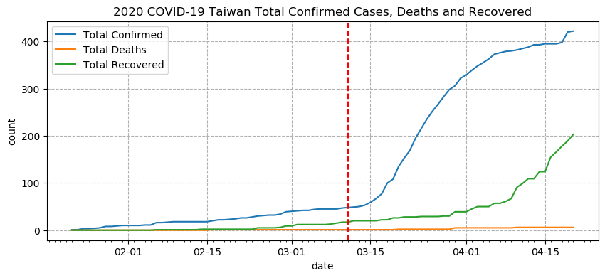

```python
plt.rcParams['font.sans-serif'] = ['DejaVuSans']
Covid19_Taiwan_overall = Covid19_Taiwan_overall.relabel('Confirmed', 'Total Confirmed').relabel('Deaths', 'Total Deaths').relabel('Recovered', 'Total Recovered')
date1 = pd.date_range('20200122', '20200420')
fig, ax = plt.subplots(figsize=(10, 4))
plt.plot(date1, Covid19_Taiwan_overall.column('Total Confirmed'), label = 'Total Confirmed')
plt.plot(date1, Covid19_Taiwan_overall.column('Total Deaths'), label = 'Total Deaths')
plt.plot(date1, Covid19_Taiwan_overall.column('Total Recovered'), label = 'Total Recovered')
plt.axvline (x = '20200311', ymin = 0, ymax = 1, color = 'red', ls = '--')
date_form = DateFormatter("%m-%d")
ax.xaxis.set_major_formatter(date_form)
ax.xaxis.set_minor_locator(mdates.DayLocator(interval = 1))
plt.legend()
plt.title('2020 COVID-19 Taiwan Total Confirmed Cases, Deaths and Recovered')
plt.grid(linestyle='--')
plt.xlabel('date')
plt.ylabel('count')
plt.show()
```

The red dash line in the above figure represents the time when WHO declared COVID-19 as a global pandemic.

### 4.2. Relations between Total Confirmed Cases, Deaths and Recovered

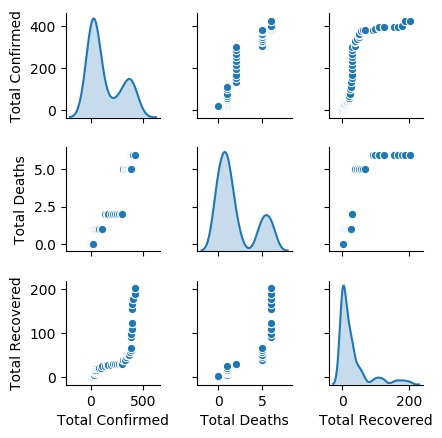

```python
sns.pairplot(Table.to_df(Covid19_Taiwan_overall.drop('ObservationDate')), height = 1.5, diag_kind='kde')
plt.show()
```

From the above pair plot, it can be concluded that:

1. **The total of confirmed cases increases rapidly than the total deaths and recovered cases in the beginning.**
2. **The total of recovered cases is stably increasing and the increasing rate is relatively faster than the total of confirmed cases and much faster than the total of deaths now.**
3. **The growth of deaths is not continuous and the amount is relatively smaller compared with the total of confirmed cases and recovered cases.**

## 5. Conclusions

In this project, the situation of COVID-19 in Taiwan has been examined in different aspects, including the current trend, distribution of confirmed cases and relations between variables. The conclusions are as follows:

1. **The amount of confirmed cases is still increasing but the increasing rate is relatively slow compared with one month before.**
2. **The total of deaths is less than 1.5% of the total of confirmed cases.**
3. **More than 80% of the confirmed cases are imported cases and most of the confirmed cases are in the north part of Taiwan, especially the capital, *Taipei City*.**
4. **Currently, the amount of recovery cases is increasing stably and faster than the confirmed cases and deaths.**

Taiwan noticed the situation of coronavirus at the end of 2019. The government started implementing measures such as isolation and quarantine to contain the coronavirus and people started wearing masks and taking other precaution to prevent the virus from spreading from the beginning of February. During the past one month after WHO declared COVID-19 as a global pandemic, the total confirmed cases has increased to more than 400 cases in Taiwan. However, more than 80% of the confirmed cases are imported cases while the daily increasing rate starts decreasing and tends to be stable after late March. On the other hand, the growth of recovered cases is faster than both the confirmed cases and deaths. This result shows that COVID-19 is under controlled in Taiwan. The government's measures and promoted precautions effectively prevent the coronavirus from causing more infections.

## STAY HOME AND STAY SAFE

Thank you for your reading.  
Questions and discussions are welcomed, please contact via email: tommy11305@gmail.com.